# R Notebook

## Visualización de los resultados

Podemos visualizar los resultados obtenidos de diferentes formas. En primer lugar podemos mostrar en un gráfico de barras cuáles de las 8 emociones son las más presentes en los tweets. Para ello, para cada barra se van a sumar los valores de la columna de la emoción correspondiente, para después sumar el resultado de todas las emociones y finalmente dividir cada suma de cada emoción entre el total.

```r
barplot(colSums(prop.table(sentimientos[,1:8])), space=0.2, horiz=FALSE, las=1, xlab="Emociones", ylab=NULL, cex.names=0.8, col=brewer.pal(n=8,name="Set2"))
```

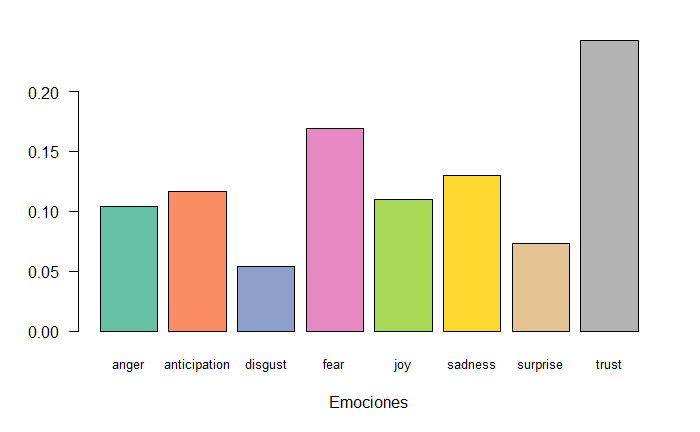

Podemos también visualizar estos mismos resultados por usuario.

```r
barplot(colSums(prop.table(sentimientos_arrimadas[,1:8])), space=0.2, horiz=FALSE, las=1, xlab="Emociones InesArrimadas", ylab=NULL, cex.names=0.8, col=brewer.pal(n=8,name="Set2"))
```

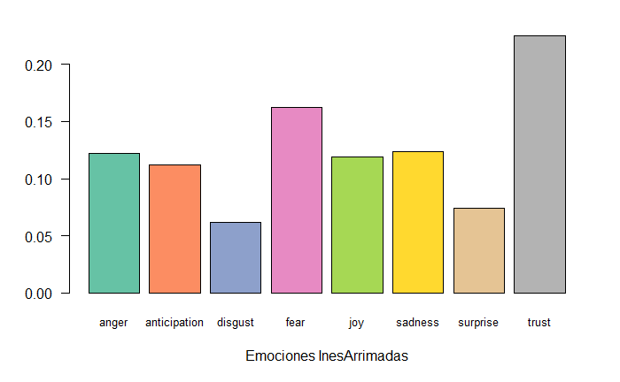

```r
barplot(colSums(prop.table(sentimientos_casado[,1:8])), space=0.2, horiz=FALSE, las=1, xlab="Emociones pablocasado_", ylab=NULL, cex.names=0.8, col=brewer.pal(n=8,name="Set2"))
```

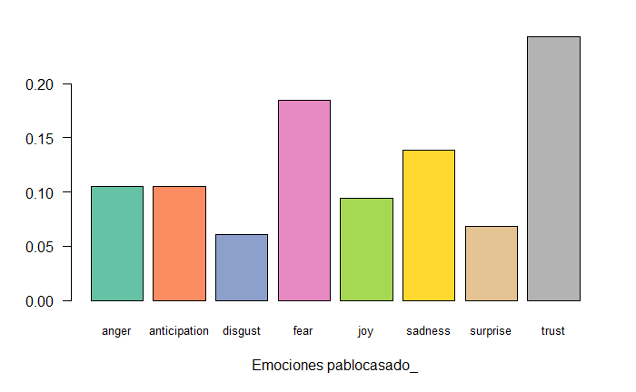

```r
barplot(colSums(prop.table(sentimientos_iglesias[,1:8])), space=0.2, horiz=FALSE, las=1, xlab="Emociones PabloIglesias", ylab=NULL, cex.names=0.8, col=brewer.pal(n=8,name="Set2"))
```

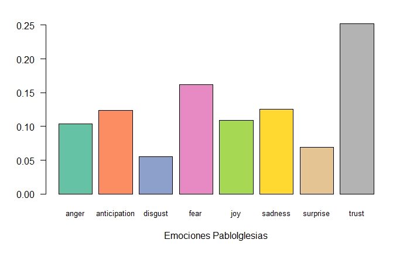

```r
barplot(colSums(prop.table(sentimientos_sanchez[,1:8])), space=0.2, horiz=FALSE, las=1, xlab="Emociones sanchezcastejon", ylab=NULL, cex.names=0.8, col=brewer.pal(n=8,name="Set2"))
```

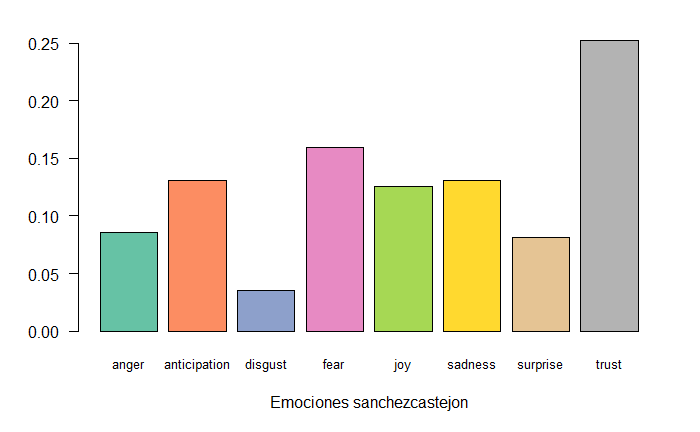

Vamos a mostrar un gráfico en el que podemos observar estos políticos agrupados por las distintas emociones.

```r
                                enfado<-c(sum(sentimientos_casado$anger),sum(sentimientos_arrimadas$anger),sum(sentimientos_iglesias$anger),sum(sentimientos_sanchez$anger))
                                  anticipacion<-c(sum(sentimientos_casado$anticipation),sum(sentimientos_arrimadas$anticipation),sum(sentimientos_iglesias$anticipation),sum(sentimientos_sanchez$anticipation))
                                  disgusto<-c(sum(sentimientos_casado$disgust),sum(sentimientos_arrimadas$disgust),sum(sentimientos_iglesias$disgust),sum(sentimientos_sanchez$disgust))
                                  miedo<-c(sum(sentimientos_casado$fear),sum(sentimientos_arrimadas$fear),sum(sentimientos_iglesias$fear),sum(sentimientos_sanchez$fear))
                                  alegria<-c(sum(sentimientos_casado$joy),sum(sentimientos_arrimadas$joy),sum(sentimientos_iglesias$joy),sum(sentimientos_sanchez$joy))
                                  tristeza<-c(sum(sentimientos_casado$sadness),sum(sentimientos_arrimadas$sadness),sum(sentimientos_iglesias$sadness),sum(sentimientos_sanchez$sadness))
                                  sorpresa<-c(sum(sentimientos_casado$surprise),sum(sentimientos_arrimadas$surprise),sum(sentimientos_iglesias$surprise),sum(sentimientos_sanchez$surprise))
                                  confianza<-c(sum(sentimientos_casado$trust),sum(sentimientos_arrimadas$trust),sum(sentimientos_iglesias$trust),sum(sentimientos_sanchez$trust))

politicos <- c(rep(c("Casado","Arrimadas","Iglesias","Sánchez"),8))

emociones <- c(rep("enfado",4), rep("anticipación",4), rep("disgusto",4), rep("miedo",4), rep("alegría",4), rep("tristeza",4), rep("sorpresa",4), rep("confianza",4))

valores <- c(enfado, anticipacion, disgusto, miedo, alegria, tristeza, sorpresa, confianza)

emociones_conjuntas <- data.frame(politicos, emociones, valores)


ggplot(data=emociones_conjuntas, aes(x=emociones, y=valores, fill=politicos))+ xlab("Emociones") + ylab("Nº palabras clasificadas según emoción") + geom_bar(stat="identity", position="dodge") + scale_fill_manual("Leyenda", values = c("Arrimadas" = "orange", "Casado" = "#0887F5", "Iglesias" = "#A755F5", "Sánchez"="#EB3100"))
```

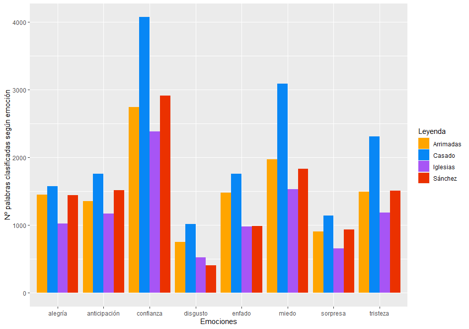

## Recuento de palabras con cada emoción

Puede ser interesante conocer qué palabras son las más usadas en función a la emoción. Para ello vamos a comparar los resultados con las emociones de *joy* y *sadness*, tal y como se muestra a continuación.

```r
#
# Casado
#

palabras_sadness_casado <- tweets_sentimientos_casado$token[sentimientos_casado$sadness > 0]
palabras_sadness_casado_ordenadas <- sort(table(unlist(palabras_sadness_casado)), decreasing=TRUE)

#Mostramos las primeras 10 palabras
head(palabras_sadness_casado_ordenadas, n=10)

 #     crisis     pandemia         peor        dejar       evitar desempleados       choque
 #        159          149           64           53           42           41           36
 # terrorismo   socialista        fondo
 #         30           27           26


palabras_joy_casado <- tweets_sentimientos_casado$token[sentimientos_casado$joy > 0]
palabras_joy_casado_ordenadas <- sort(table(unlist(palabras_joy_casado)), decreasing=TRUE)

#Mostramos las primeras 10 palabras
head(palabras_joy_casado_ordenadas, n=10)

# libertad independencia         crear      especial      igualdad       defensa
#      184            47            38            36            36            34
#  trabajo        abrazo       acuerdo       mejorar
#       33            32            28            28


#Podemos ver las palabras que han sido relacionadas con tristeza y felicidad, respectivamente
length(palabras_sadness_casado_ordenadas)
#270

length(palabras_joy_casado_ordenadas)
#172
```

Parece interesante en los resultados ver que palabras como *socialista* es negativa. Ésto puede deberse a los problemas de traducción previamente mencionados. También podríamos eliminarla añadiéndola como stop word y realizar de nuevo el análisis, pero en nuestro estudio no nos interesa.

```r
#
# Arrimadas
#

palabras_sadness_arrimadas <- tweets_sentimientos_arrimadas$token[sentimientos_arrimadas$sadness > 0]
palabras_sadness_arrimadas_ordenadas <- sort(table(unlist(palabras_sadness_arrimadas)), decreasing=TRUE)

#Mostramos las primeras 10 palabras
head(palabras_sadness_arrimadas_ordenadas, n=10)

#   crisis  pandemia     lucha violencia  terrible     dejar      peor      odio    evitar
#      110        86        47        29        28        26        25        21        20
# problema
#       20


palabras_joy_arrimadas <- tweets_sentimientos_arrimadas$token[sentimientos_arrimadas$joy > 0]
palabras_joy_arrimadas_ordenadas <- sort(table(unlist(palabras_joy_arrimadas)), decreasing=TRUE)

#Mostramos las primeras 10 palabras
head(palabras_joy_arrimadas_ordenadas, n=10)

# libertad igualdad  trabajo  orgullo   abrazo  acuerdo especial      paz   dinero    feliz
#      156       82       76       44       36       35       35       35       29       28

#Podemos ver las palabras que han sido relacionadas con tristeza y felicidad, respectivamente
length(palabras_sadness_arrimadas_ordenadas)
#223

length(palabras_joy_arrimadas_ordenadas)
#155
```

```r
#
# Iglesias
#

palabras_sadness_iglesias <- tweets_sentimientos_iglesias$token[sentimientos_iglesias$sadness > 0]
palabras_sadness_iglesias_ordenadas <- sort(table(unlist(palabras_sadness_iglesias)), decreasing=TRUE)

#Mostramos las primeras 10 palabras
head(palabras_sadness_iglesias_ordenadas, n=10)

# crisis compromiso  violencia   pandemia      lucha   artículo  dictadura emergencia  necesidad       odio
#    104         54         34         33         26         25         24         24         24         20


palabras_joy_iglesias <- tweets_sentimientos_iglesias$token[sentimientos_iglesias$joy > 0]
palabras_joy_iglesias_ordenadas <- sort(table(unlist(palabras_joy_iglesias)), decreasing=TRUE)

#Mostramos las primeras 10 palabras
head(palabras_joy_iglesias_ordenadas, n=10)

# trabajo  acuerdo libertad igualdad   abrazo  defensa  avanzar  orgullo     voto victoria
#      68       61       42       33       26       26       24       20       18       16

#Podemos ver las palabras que han sido relacionadas con tristeza y felicidad, respectivamente
length(palabras_sadness_iglesias_ordenadas)
#211

length(palabras_joy_iglesias_ordenadas)
#162
```

```r
#
# Sánchez
#

palabras_sadness_sanchez <- tweets_sentimientos_sanchez$token[sentimientos_sanchez$sadness > 0]
palabras_sadness_sanchez_ordenadas <- sort(table(unlist(palabras_sadness_sanchez)), decreasing=TRUE)

#Mostramos las primeras 10 palabras
head(palabras_sadness_sanchez_ordenadas, n=10)

# pandemia compromiso     crisis emergencia      lucha  violencia      dejar       odio      fondo  necesidad
#      172        102         97         70         55         40         38         31         28         21


palabras_joy_sanchez <- tweets_sentimientos_sanchez$token[sentimientos_sanchez$joy > 0]
palabras_joy_sanchez_ordenadas <- sort(table(unlist(palabras_joy_sanchez)), decreasing=TRUE)

#Mostramos las primeras 10 palabras
head(palabras_joy_sanchez_ordenadas, n=10)

# igualdad  trabajo  acuerdo  avanzar progreso libertad    verde   lograr recursos   abrazo
#       90       84       80       80       50       48       46       45       39       34

#Podemos ver las palabras que han sido relacionadas con tristeza y felicidad, respectivamente
length(palabras_sadness_sanchez_ordenadas)
#169

length(palabras_joy_sanchez_ordenadas)
#147
```

## Nube de emociones

El objetivo de este apartado es crear una nube parecida al *word cloud* creado anteriormente en este cuaderno, pero en este caso tendremos las palabras situadas en un lado u otro en función de los ocho sentimientos. Pasamos entonces a guardar todas las palabras en un vector para después crear la nube.

```r
#
# Casado
#

vector_nube_emociones <- c(paste(tweets_sentimientos_casado$token[sentimientos_casado$sadness > 0], collapse=" "),
                           paste(tweets_sentimientos_casado$token[sentimientos_casado$joy > 0], collapse=" "),
                           paste(tweets_sentimientos_casado$token[sentimientos_casado$anger > 0], collapse=" "),
                           paste(tweets_sentimientos_casado$token[sentimientos_casado$fear > 0], collapse=" "),
                           paste(tweets_sentimientos_casado$token[sentimientos_casado$anticipation > 0], collapse=" "),
                           paste(tweets_sentimientos_casado$token[sentimientos_casado$disgust > 0], collapse=" "),
                           paste(tweets_sentimientos_casado$token[sentimientos_casado$trust > 0], collapse=" "),
                           paste(tweets_sentimientos_casado$token[sentimientos_casado$surprise > 0], collapse=" "))

vector_nube_emociones <- iconv(vector_nube_emociones, from="UTF-8", to="UTF-8")

#Creamos un corpus de palabras con ocho "documentos"
corpus_nube <- Corpus(VectorSource(vector_nube_emociones))

#Transformamos a matriz
nube <- TermDocumentMatrix(corpus_nube)
nube <- as.matrix(nube)

#Cambiamos los nombres de las columnas
colnames(nube) <- c("tristeza", "alegría", "enfado", "miedo", "anticipación","disgusto","confianza","sorpresa")
head(nube)

#            Docs
# Terms        tristeza alegría enfado miedo anticipación disgusto confianza sorpresa
#   abandonado        5       0      5     5            0        0         0        0
#   abandonar         7       0      0     7            0        0         0        0
#   abandono         10       0     10    10            0        0         0       10
#   abismo            1       0      0     1            0        0         0        0
#   aborto            1       0      0     1            0        1         0        0
#   abuso             1       0      1     1            0        1         0        0
```

Llegados a este punto, hacemos uso de la función *comparison.cloud* del paquete *wordcloud* anteriormente usado para la representación de la nube de emociones.

```r
comparison.cloud(nube, title.size = 1, max.words = 50, scale = c(2.5,1), rot.per = 0.4)
```

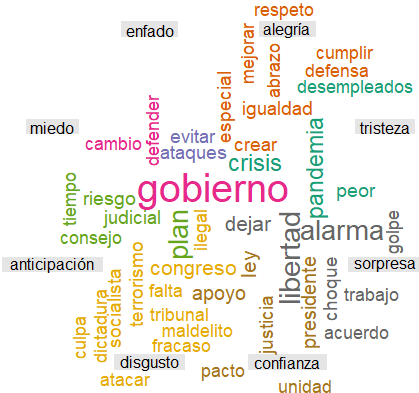

```r
#
# Arrimadas
#

vector_nube_emociones_arrimadas <- c(paste(tweets_sentimientos_arrimadas$token[sentimientos_arrimadas$sadness > 0], collapse=" "),
                           paste(tweets_sentimientos_arrimadas$token[sentimientos_arrimadas$joy > 0], collapse=" "),
                           paste(tweets_sentimientos_arrimadas$token[sentimientos_arrimadas$anger > 0], collapse=" "),
                           paste(tweets_sentimientos_arrimadas$token[sentimientos_arrimadas$fear > 0], collapse=" "),
                           paste(tweets_sentimientos_arrimadas$token[sentimientos_arrimadas$anticipation > 0], collapse=" "),
                           paste(tweets_sentimientos_arrimadas$token[sentimientos_arrimadas$disgust > 0], collapse=" "),
                           paste(tweets_sentimientos_arrimadas$token[sentimientos_arrimadas$trust > 0], collapse=" "),
                           paste(tweets_sentimientos_arrimadas$token[sentimientos_arrimadas$surprise > 0], collapse=" "))

vector_nube_emociones_arrimadas <- iconv(vector_nube_emociones_arrimadas, from="UTF-8", to="UTF-8")

#Creamos un corpus de palabras con ocho "documentos"
corpus_nube_arrimadas <- Corpus(VectorSource(vector_nube_emociones_arrimadas))

#Transformamos a matriz
nube_arrimadas <- TermDocumentMatrix(corpus_nube_arrimadas)
nube_arrimadas <- as.matrix(nube_arrimadas)

#Cambiamos los nombres de las columnas
colnames(nube_arrimadas) <- c("tristeza", "alegría", "enfado", "miedo", "anticipación","disgusto","confianza","sorpresa")
head(nube_arrimadas)

#              Docs
# Terms         tristeza alegría enfado miedo anticipación disgusto confianza sorpresa
#   abandonado         1       0      1     1            0        0         0        0
#   abandonar          7       0      0     7            0        0         0        0
#   abandono          14       0     14    14            0        0         0       14
#   abismo             1       0      0     1            0        0         0        0
#   accidente          6       0      0     6            0        0         0        6
#   acompañarte        1       1      0     0            1        0         0        1


comparison.cloud(nube_arrimadas, title.size = 1, max.words = 50, scale = c(2.5,1), rot.per = 0.4)
```

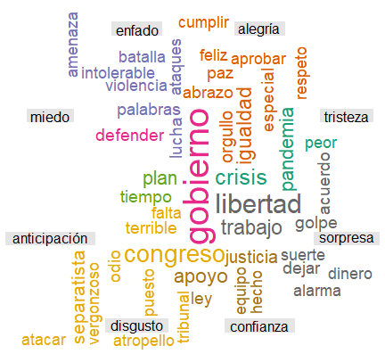

```r
#
# Iglesias
#

vector_nube_emociones_iglesias <- c(paste(tweets_sentimientos_iglesias$token[sentimientos_iglesias$sadness > 0], collapse=" "),
                           paste(tweets_sentimientos_iglesias$token[sentimientos_iglesias$joy > 0], collapse=" "),
                           paste(tweets_sentimientos_iglesias$token[sentimientos_iglesias$anger > 0], collapse=" "),
                           paste(tweets_sentimientos_iglesias$token[sentimientos_iglesias$fear > 0], collapse=" "),
                           paste(tweets_sentimientos_iglesias$token[sentimientos_iglesias$anticipation > 0], collapse=" "),
                           paste(tweets_sentimientos_iglesias$token[sentimientos_iglesias$disgust > 0], collapse=" "),
                           paste(tweets_sentimientos_iglesias$token[sentimientos_iglesias$trust > 0], collapse=" "),
                           paste(tweets_sentimientos_iglesias$token[sentimientos_iglesias$surprise > 0], collapse=" "))

vector_nube_emociones_iglesias <- iconv(vector_nube_emociones_iglesias, from="UTF-8", to="UTF-8")

#Creamos un corpus de palabras con ocho "documentos"
corpus_nube_iglesias <- Corpus(VectorSource(vector_nube_emociones_iglesias))

#Transformamos a matriz
nube_iglesias <- TermDocumentMatrix(corpus_nube_iglesias)
nube_iglesias <- as.matrix(nube_iglesias)

#Cambiamos los nombres de las columnas
colnames(nube_iglesias) <- c("tristeza", "alegría", "enfado", "miedo", "anticipación","disgusto","confianza","sorpresa")
head(nube_iglesias)

#              Docs
# Terms         tristeza alegría enfado miedo anticipación disgusto confianza sorpresa
#   abandonar          1       0      0     1            0        0         0        0
#   abandonarán        1       0      0     1            0        0         0        0
#   abandono           4       0      4     4            0        0         0        4
#   absurdo            2       0      0     0            0        2         0        0
#   abuso              1       0      1     1            0        1         0        0
#   accidente          4       0      0     4            0        0         0        4


comparison.cloud(nube_iglesias, title.size = 1, max.words = 50, scale = c(2.5,1), rot.per = 0.4)
```

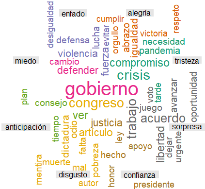

```r
#
# Sánchez
#

vector_nube_emociones_sanchez <- c(paste(tweets_sentimientos_sanchez$token[sentimientos_sanchez$sadness > 0], collapse=" "),
                           paste(tweets_sentimientos_sanchez$token[sentimientos_sanchez$joy > 0], collapse=" "),
                           paste(tweets_sentimientos_sanchez$token[sentimientos_sanchez$anger > 0], collapse=" "),
                           paste(tweets_sentimientos_sanchez$token[sentimientos_sanchez$fear > 0], collapse=" "),
                           paste(tweets_sentimientos_sanchez$token[sentimientos_sanchez$anticipation > 0], collapse=" "),
                           paste(tweets_sentimientos_sanchez$token[sentimientos_sanchez$disgust > 0], collapse=" "),
                           paste(tweets_sentimientos_sanchez$token[sentimientos_sanchez$trust > 0], collapse=" "),
                           paste(tweets_sentimientos_sanchez$token[sentimientos_sanchez$surprise > 0], collapse=" "))

vector_nube_emociones_sanchez <- iconv(vector_nube_emociones_sanchez, from="UTF-8", to="UTF-8")

#Creamos un corpus de palabras con ocho "documentos"
corpus_nube_sanchez <- Corpus(VectorSource(vector_nube_emociones_sanchez))

#Transformamos a matriz
nube_sanchez <- TermDocumentMatrix(corpus_nube_sanchez)
nube_sanchez <- as.matrix(nube_sanchez)

#Cambiamos los nombres de las columnas
colnames(nube_sanchez) <- c("tristeza", "alegría", "enfado", "miedo", "anticipación","disgusto","confianza","sorpresa")
head(nube_sanchez)

#               Docs
# Terms          tristeza alegría enfado miedo anticipación disgusto confianza sorpresa
#   abandonado          1       0      1     1            0        0         0        0
#   abandonar           4       0      0     4            0        0         0        0
#   abandonará          1       0      0     1            0        0         0        0
#   aborto              2       0      0     2            0        2         0        0
#   absurdo             1       0      0     0            0        1         0        0
#   aburrimiento        1       0      0     0            0        0         0        0

comparison.cloud(nube_sanchez, title.size = 1, max.words = 50, scale = c(2.5,1), rot.per = 0.4)
```

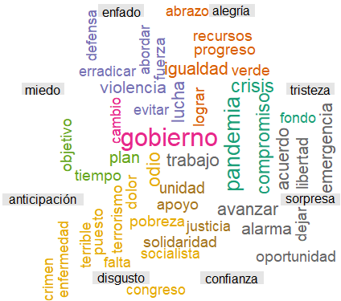

## Evolución de emociones

Para hacer una comparativa conjunta a lo largo del tiempo de los distintos políticos, vamos a recoger sus tweets en el mismo intervalo temporal. Este intervalo será desde el 04/02/2020 hasta el 04/05/2021.

```r
sentimientos_casado_evolucion <- subset(tweets_sentimientos_casado, fecha >= "2020-02-04" & fecha <= "2021-05-04")
sentimientos_arrimadas_evolucion <- subset(tweets_sentimientos_arrimadas, fecha >= "2020-02-04" & fecha <= "2021-05-04")
sentimientos_iglesias_evolucion <- subset(tweets_sentimientos_iglesias, fecha >= "2020-02-04" & fecha <= "2021-05-04")
sentimientos_sanchez_evolucion <- subset(tweets_sentimientos_sanchez, fecha >= "2020-02-04" & fecha <= "2021-05-04")
```

Y volvemos a preparar los datos para su posterior estudio:

```r
sentimientos_casado_evolucion <- get_nrc_sentiment(sentimientos_casado_evolucion$token,language = "spanish")
sentimientos_arrimadas_evolucion <- get_nrc_sentiment(sentimientos_arrimadas_evolucion$token,language = "spanish")
sentimientos_iglesias_evolucion <- get_nrc_sentiment(sentimientos_iglesias_evolucion$token,language = "spanish")
sentimientos_sanchez_evolucion <- get_nrc_sentiment(sentimientos_sanchez_evolucion$token,language = "spanish")
```

Se podría también hacer un estudio evolutivo de las palabras por usuario en función de su polaridad. Para ello, habría que normalizar los datos que tenemos, ya que una palabra se considera positiva cuando su valor se acerca a 1, y negativa cuando se acerca a -1, considerando el 0 como neutro. Esto se calcula multiplicando los valores de la columna de valores negativos por -1 y sumando el valor de la columna de valores positivos, tal y como se muestra.

```r
valor_sentimientos_casado_evolucion <- (sentimientos_casado_evolucion$negative * (-1)) + sentimientos_casado_evolucion$positive
valor_sentimientos_arrimadas_evolucion <- (sentimientos_arrimadas_evolucion$negative * (-1)) + sentimientos_arrimadas_evolucion$positive
valor_sentimientos_iglesias_evolucion <- (sentimientos_iglesias_evolucion$negative * (-1)) + sentimientos_iglesias_evolucion$positive
valor_sentimientos_sanchez_evolucion <- (sentimientos_sanchez_evolucion$negative * (-1)) + sentimientos_sanchez_evolucion$positive
```

Pasamos entonces a representar la evolución de los sentimientos, de forma que en la primera imagen tiene todas las medidas que el algoritmo utiliza y calcula (Loess Smooth, rolling mean y discrete cosine transformation), y la segunda es una normalización del DCT. Es importante el uso de esta representación pues suaviza los resultados y podemos ver cómo evolucionan los sentimientos a lo largo del tiempo de una forma más clara.

```r
simple_plot(valor_sentimientos_casado_evolucion)
```

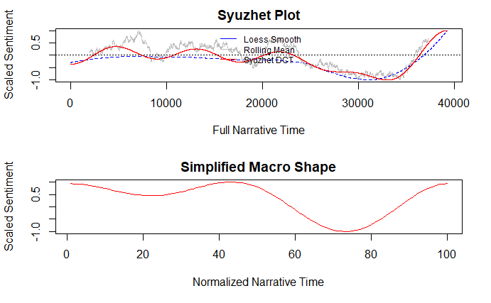

```r
simple_plot(valor_sentimientos_arrimadas_evolucion)
```

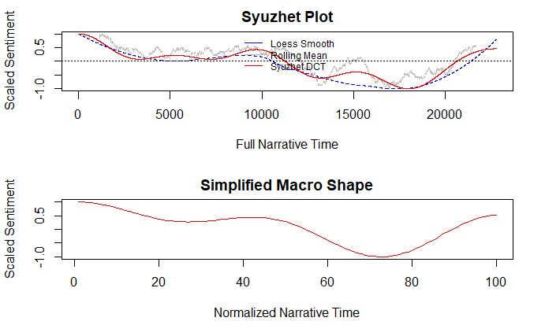

```r
simple_plot(valor_sentimientos_iglesias_evolucion)
```

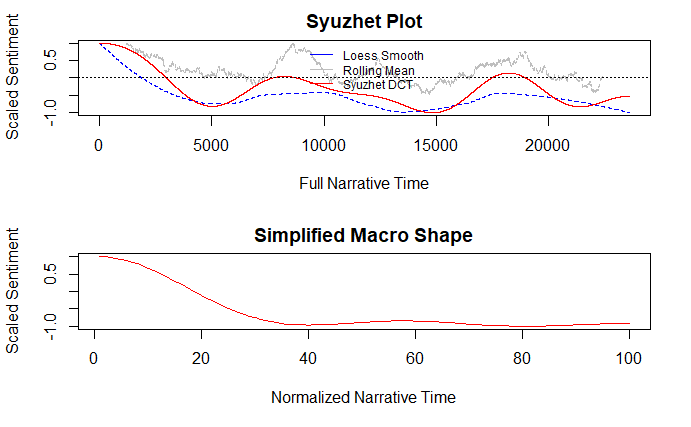

```r
simple_plot(valor_sentimientos_sanchez_evolucion)
```

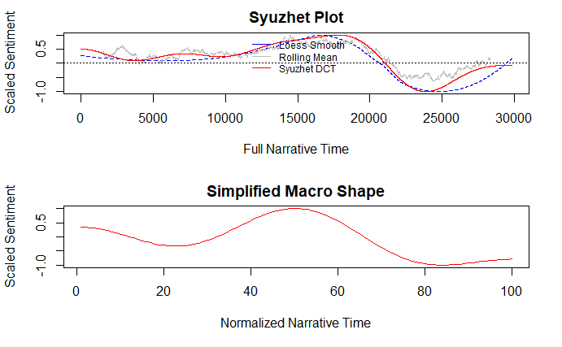